# ETC5512: Wild Caught Data – ETC5512

## ETC5512

### Combining Australian census and election data

Lecturer: *Kate Saunders*

Department of Econometrics and Business Statistics

- ETC5512.Clayton-x@monash.edu
- Wild Caught Data
- wcd.numbat.space

## Today’s Lecture

**What we’ll cover**

Today you will:

- look at the ABS geographical boundaries for the 2021 census
- integrate data from different sources (census and election) to make exploratory inferences

**From a coding perspective:**

- Further expand our understanding of how to read and use spatial data in R
- Better understand how spatial data is organised
- Learn how to intersect two spatial objections
- Practice re-projecting maps

# Recap

## Recall Lecture 5: 2021 Federal Election Data

```r
library(tidyverse)
library(sf)

aec_map <- read_sf(here::here("data/vic-july-2021-esri/E_VIC21_region.shp"))

votes <- read_csv("https://results.aec.gov.au/27966/Website/Downloads/HouseDopByDivisionDownload-27966.csv", skip = 1)

electoral_winners = votes |>
  mutate(DivisionNm = toupper(DivisionNm)) |>
  filter(Elected == "Y") |>
  select(PartyAb, DivisionID, DivisionNm, Elected) |>
  distinct()

aec_map = aec_map |>
  mutate(Elect_div = toupper(Elect_div))

winners_with_map = electoral_winners |>
  left_join(aec_map, by = c("DivisionNm" = "Elect_div"))

aus_colours <- c(
  "ALP" = "#DE3533", "LNP" = "#ADD8E6", "KAP" = "#8B0000", "GVIC" = "#10C25B", "XEN" = "#ff6300",
  "LP" = "#0047AB", "NP" = "#0a9cca", "IND" = "#000000"
)

winners_plot <- ggplot(winners_with_map) +
  geom_sf(aes(fill = PartyAb, geometry = geometry)) +
  scale_fill_manual(values = aus_colours)
```

## Recall Lecture 5: 2021 Federal Election Data

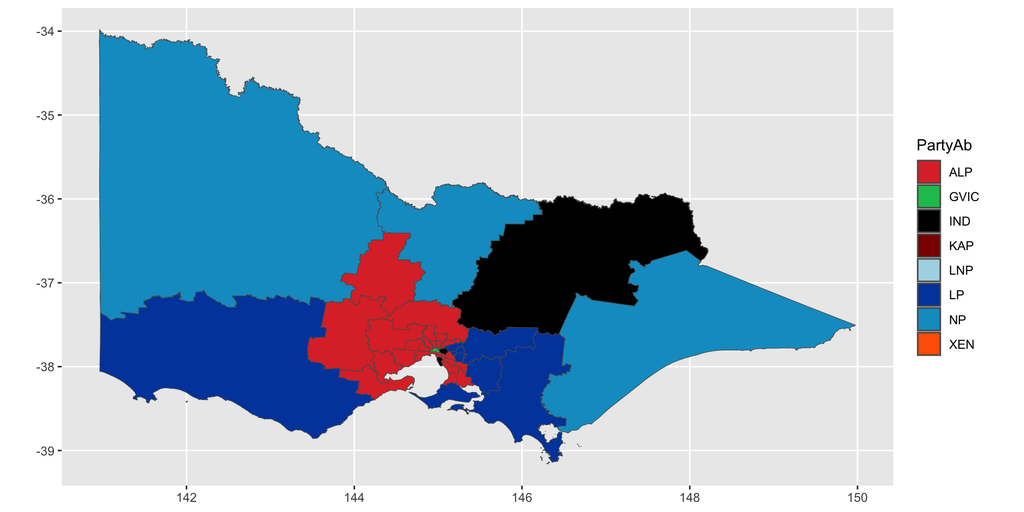

There are two sources of data:

1. Electoral boundary
2. The votes for candidates in each electorate

## Recall Lecture 6: 2021 ABS Census Data

There are two main types of data that you can download.

- DataPacks: https://www.abs.gov.au/census/find-census-data/datapacks
- GeoPackages: [https://www.abs.gov.au/census/find-census-data/geopackages](https://www.abs.gov.au/census/find-census-data/datapacks)

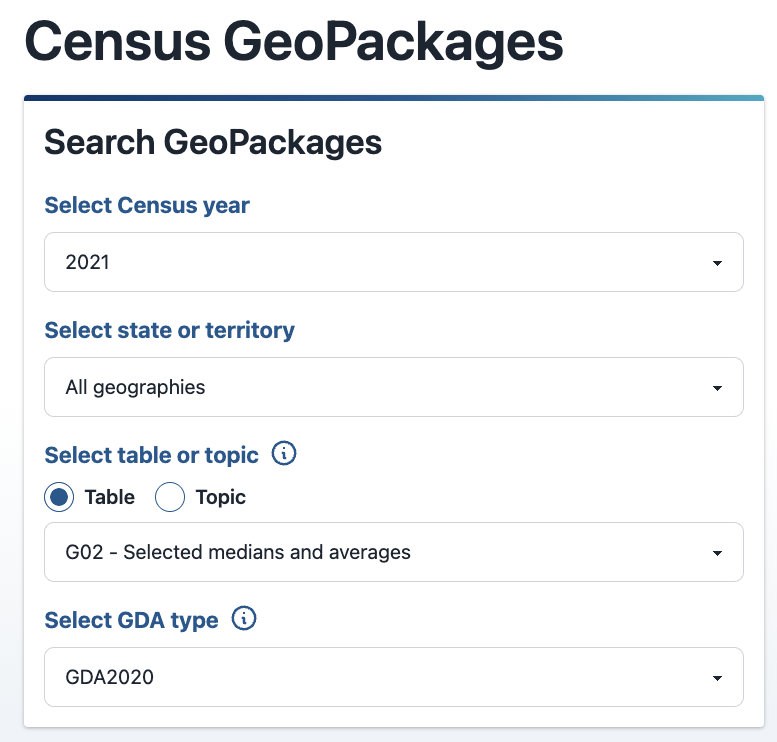

# ABS Census 2021: GeoPackages

## GeoPackage

> A **GeoPackage** (GPKG) is an open, non-proprietary, platform-independent and standards-based data format for geographic information system implemented as a SQLite database container. Defined by the **Open Geospatial Consortium** (OGC) with the backing of the US military and published in 2014, GeoPackage has seen widespread support from various government, commercial, and open source organizations. *https://en.wikipedia.org/wiki/GeoPackage*

Recall: OGC also defines the WKT (basically how the maps is drawn.)

## ABS GeoPackage (2021)

**Download the data**

https://datapacks.censusdata.abs.gov.au/geopackages/

1. 2021
2. Victoria
3. Topic: Employment and Income or Table: G02
4. GDA2020

*You may also like to check out the [`strayr`](https://github.com/runapp-aus/strayr) R package!*

## ABS GeoPackage (2021)

```r
geopath_2021_G02 <- here::here("data/Geopackage_2021_G02_VIC_GDA2020/G02_VIC_GDA2020.gpkg")
st_layers(geopath_2021_G02)
```

```
Driver: GPKG
Available layers:
           layer_name geometry_type features fields crs_name
1    G02_UCL_2021_VIC Multi Polygon      347     11  GDA2020
2    G02_SUA_2021_VIC Multi Polygon       22     11  GDA2020
3    G02_STE_2021_VIC Multi Polygon        1     11  GDA2020
4   G02_SOSR_2021_VIC Multi Polygon       12     11  GDA2020
5    G02_SOS_2021_VIC Multi Polygon        6     11  GDA2020
6    G02_SED_2021_VIC Multi Polygon       90     11  GDA2020
7    G02_SAL_2021_VIC Multi Polygon     2946     11  GDA2020
8    G02_SA4_2021_VIC Multi Polygon       19     11  GDA2020
9    G02_SA3_2021_VIC Multi Polygon       68     11  GDA2020
10   G02_SA2_2021_VIC Multi Polygon      524     11  GDA2020
11   G02_SA1_2021_VIC Multi Polygon    15482     11  GDA2020
12   G02_POA_2021_VIC Multi Polygon      694     11  GDA2020
13   G02_LGA_2021_VIC Multi Polygon       82     11  GDA2020
14 G02_GCCSA_2021_VIC Multi Polygon        4     11  GDA2020
15   G02_CED_2021_VIC Multi Polygon       41     11  GDA2020
16    G02_RA_2021_VIC Multi Polygon        6     11  GDA2020
```

## ABS GeoPackage (2016)

**Download the data (Notice it is stored differently)**

https://datapacks.censusdata.abs.gov.au/geopackages/

1. 2016
2. Victoria
3. Employment, Income and Unpaid Work (EIUW)
4. EIUW GeoPackage A

## ABS GeoPackage (2016)

```r
geopath_2016_eiuwa <- here::here("data/Geopackage_2016_EIUWA_for_VIC/census2016_eiuwa_vic_short.gpkg")
st_layers(geopath_2016_eiuwa)
```

```
Driver: GPKG
Available layers:
                         layer_name geometry_type features fields crs_name
1    census2016_eiuwa_vic_ced_short                     39    489    GDA94
2  census2016_eiuwa_vic_gccsa_short                      4    489    GDA94
3    census2016_eiuwa_vic_lga_short                     82    489    GDA94
4    census2016_eiuwa_vic_poa_short                    698    489    GDA94
5     census2016_eiuwa_vic_ra_short                      6    489    GDA94
6    census2016_eiuwa_vic_sa1_short                  14073    489    GDA94
7    census2016_eiuwa_vic_sa2_short                    464    489    GDA94
8    census2016_eiuwa_vic_sa3_short                     68    489    GDA94
9    census2016_eiuwa_vic_sa4_short                     19    489    GDA94
10   census2016_eiuwa_vic_sed_short                     90    489    GDA94
11   census2016_eiuwa_vic_sos_short                      6    489    GDA94
12  census2016_eiuwa_vic_sosr_short                     12    489    GDA94
13   census2016_eiuwa_vic_ssc_short                   2931    489    GDA94
14   census2016_eiuwa_vic_ste_short                      1    489    GDA94
15   census2016_eiuwa_vic_sua_short                     22    489    GDA94
16   census2016_eiuwa_vic_ucl_short                    353    489    GDA94
```

## The Australian Statistical Geography Standard (ASGS)

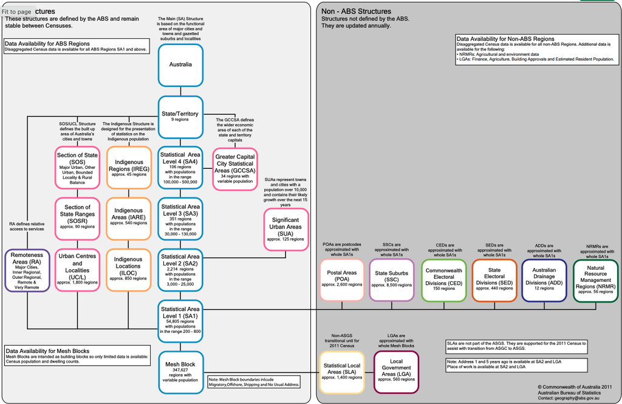

## The number of regions for each layer

```
# A tibble: 16 × 6
   name               geomtype  driver features fields crs
   <chr>              <list>    <chr>     <dbl>  <dbl> <list>
 1 G02_STE_2021_VIC   <chr [1]> GPKG          1     11 <crs>
 2 G02_GCCSA_2021_VIC <chr [1]> GPKG          4     11 <crs>
 3 G02_SOS_2021_VIC   <chr [1]> GPKG          6     11 <crs>
 4 G02_RA_2021_VIC    <chr [1]> GPKG          6     11 <crs>
 5 G02_SOSR_2021_VIC  <chr [1]> GPKG         12     11 <crs>
 6 G02_SA4_2021_VIC   <chr [1]> GPKG         19     11 <crs>
 7 G02_SUA_2021_VIC   <chr [1]> GPKG         22     11 <crs>
 8 G02_CED_2021_VIC   <chr [1]> GPKG         41     11 <crs>
 9 G02_SA3_2021_VIC   <chr [1]> GPKG         68     11 <crs>
10 G02_LGA_2021_VIC   <chr [1]> GPKG         82     11 <crs>
11 G02_SED_2021_VIC   <chr [1]> GPKG         90     11 <crs>
12 G02_UCL_2021_VIC   <chr [1]> GPKG        347     11 <crs>
13 G02_SA2_2021_VIC   <chr [1]> GPKG        524     11 <crs>
14 G02_POA_2021_VIC   <chr [1]> GPKG        694     11 <crs>
15 G02_SAL_2021_VIC   <chr [1]> GPKG       2946     11 <crs>
16 G02_SA1_2021_VIC   <chr [1]> GPKG      15482     11 <crs>
```

## What is in a layer?

```
Geometry set for 1 feature
Geometry type: MULTIPOLYGON
Dimension:     XY
Bounding box:  xmin: 140.9619 ymin: -39.15918 xmax: 149.9762 ymax: -33.98064
Geodetic CRS:  GDA2020
```

```
sf [1 × 12] (S3: sf/tbl_df/tbl/data.frame)
 $ STE_CODE_2021                : chr "2"
 $ STE_NAME_2021                : chr "Victoria"
 $ Median_age_persons           : num 38
 $ Median_mortgage_repay_monthly: num 1859
 $ Median_tot_prsnl_inc_weekly  : num 803
 $ Median_rent_weekly           : num 370
 $ Median_tot_fam_inc_weekly    : num 2136
 $ Average_num_psns_per_bedroom : num 0.8
 $ Median_tot_hhd_inc_weekly    : num 1759
 $ Average_household_size       : num 2.5
 $ AREA_ALBERS_SQKM             : num 227496
 $ geom                         :sfc_MULTIPOLYGON of length 1; first list element: List of 157
  ..$ :List of 1
  .. ..$ : num [1:39, 1:2] 146 146 146 146 146 ...
  ..$ :List of 1
  .. ..$ : num [1:25, 1:2] 146 146 146 146 146 ...
  ..$ :List of 1
  .. ..$ : num [1:17, 1:2] 146 146 146 146 146 ...
  ..$ :List of 1
  .. ..$ : num [1:112, 1:2] 146 146 146 146 146 ...
  ..$ :List of 1
  .. ..$ : num [1:151, 1:2] 146 146 146 146 146 ...
  ..$ :List of 1
  .. ..$ : num [1:18, 1:2] 146 146 146 146 146 ...
  ..$ :List of 1
  .. ..$ : num [1:859, 1:2] 150 150 150 150 150 ...
  ..$ :List of 1
  .. ..$ : num [1:64, 1:2] 150 150 150 150 150 ...
  ..$ :List of 1
  .. ..$ : num [1:18, 1:2] 145 145 145 145 145 ...
  ..$ :List of 1
  .. ..$ : num [1:1149, 1:2] 145 145 145 145 145 ...
  ..$ :List of 1
  .. ..$ : num [1:76, 1:2] 145 145 145 145 145 ...
  ..$ :List of 1
  .. ..$ : num [1:114, 1:2] 145 145 145 145 145 ...
  ..$ :List of 1
  .. ..$ : num [1:34, 1:2] 145 145 145 145 145 ...
  ..$ :List of 1
```

[output cut: 161 more lines]

```
  ..$ :List of 1
  .. ..$ : num [1:47, 1:2] 143 143 143 143 143 ...
  ..$ :List of 1
  .. ..$ : num [1:80, 1:2] 147 147 147 147 147 ...
  ..$ :List of 1
  .. ..$ : num [1:127, 1:2] 147 147 147 147 147 ...
  ..$ :List of 1
  .. ..$ : num [1:61, 1:2] 147 147 147 147 147 ...
  ..$ :List of 1
  .. ..$ : num [1:85, 1:2] 147 147 147 147 147 ...
  .. [list output truncated]
  ..- attr(*, "class")= chr [1:3] "XY" "MULTIPOLYGON" "sfg"
 - attr(*, "sf_column")= chr "geom"
 - attr(*, "agr")= Factor w/ 3 levels "constant","aggregate",..: NA NA NA NA NA NA NA NA NA NA ...
  ..- attr(*, "names")= chr [1:11] "STE_CODE_2021" "STE_NAME_2021" "Median_age_persons" "Median_mortgage_repay_monthly" ...
```

## State or Territory (STE)

```r
vicmap_ste_G02 <- read_sf(geopath_2021_G02, layer = "G02_STE_2021_VIC")

ggplot(vicmap_ste_G02) +
  geom_sf(aes(geometry = geom, fill = Median_age_persons))
```

```r
nrow(vicmap_ste)
```

```
[1] 1
```

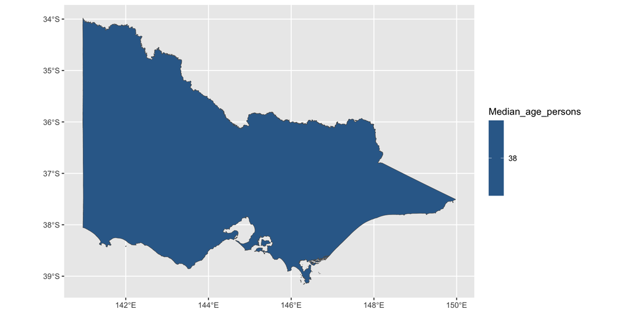

## Breakout Session

**Try it yourself time**

- Download the geopackage for the 2021 census and variable G02
- Look at how that spatial data is organised
- Look at the different layers

**What are the differences between the regionalisations?**

**How does the median age change across the different regionalisations?**

# A closer look at each region

## Greater Capital City Statistical Areas (GCCSA)

- Each region has a different population

```r
vicmap_gccsa_G02 <- read_sf(geopath_2021_G02, layer = "G02_GCCSA_2021_VIC")
ggplot(vicmap_gccsa_G02) +
  geom_sf(aes(geometry = geom, fill = Median_age_persons))
```

```r
nrow(vicmap_gccsa_G02)
```

```
[1] 4
```

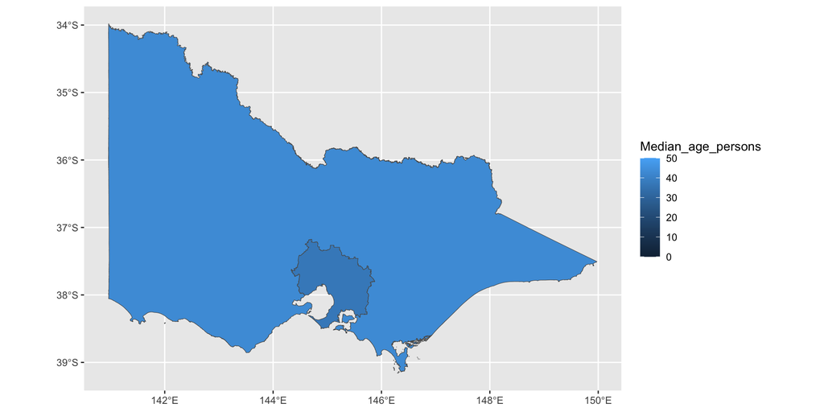

## Section of State (SOS)

- Major urban, other urban, bounded locally & rural balance

```r
vicmap_sos_G02 <- read_sf(geopath_2021_G02, layer = "G02_SOS_2021_VIC")
ggplot(vicmap_sos_G02) +
  geom_sf(aes(geometry = geom, fill = Median_age_persons))
```

```r
nrow(vicmap_sos_G02)
```

```
[1] 6
```

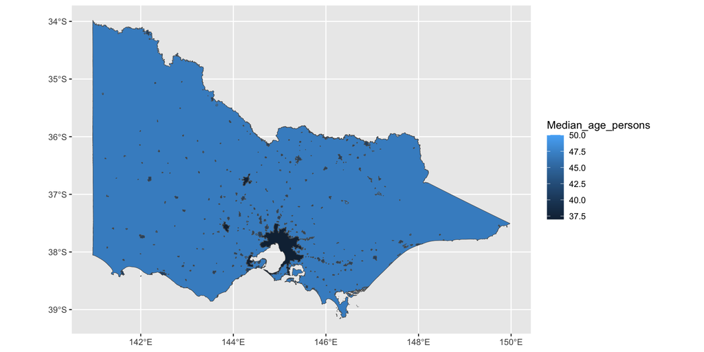

## Remoteness Areas (RA)

```r
vicmap_ra_G02 <- read_sf(geopath_2021_G02, layer = "G02_RA_2021_VIC")
ggplot(vicmap_ra_G02) +
  geom_sf(aes(geometry = geom, fill = Median_age_persons))
```

```r
nrow(vicmap_ra_G02)
```

```
[1] 6
```

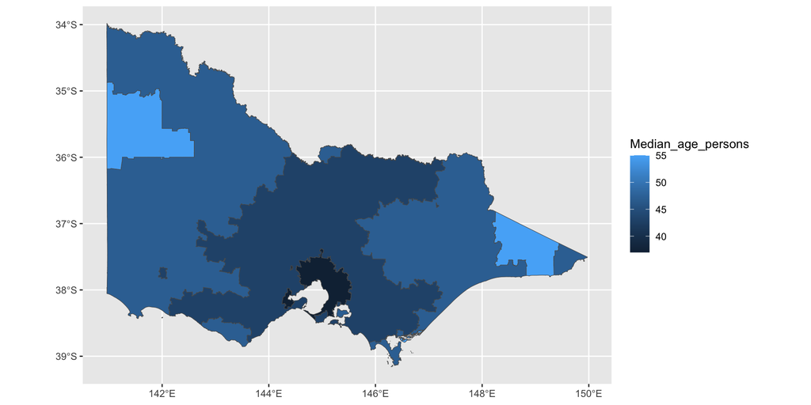

## Section of State Ranges (SOSR)

```r
vicmap_sosr_G02 <- read_sf(geopath_2021_G02, layer = "G02_SOSR_2021_VIC")
ggplot(vicmap_sosr_G02) +
  geom_sf(aes(geometry = geom, fill = Median_age_persons))
```

```r
nrow(vicmap_sosr_G02)
```

```
[1] 12
```

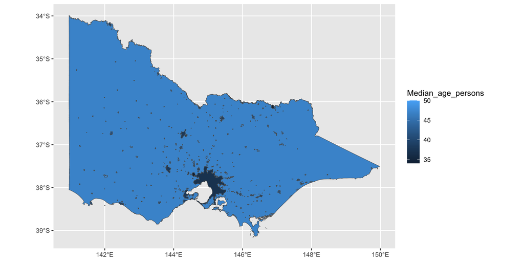

## Statistical Area Level 4 (SA4)

- Each region with population of 100,000 - 500,000

```r
vicmap_sa4_G02 <- read_sf(geopath_2021_G02, layer = "G02_SA4_2021_VIC")
ggplot(vicmap_sa4_G02) +
  geom_sf(aes(geometry = geom, fill = Median_age_persons))
```

```r
nrow(vicmap_sa4_G02)
```

```
[1] 19
```

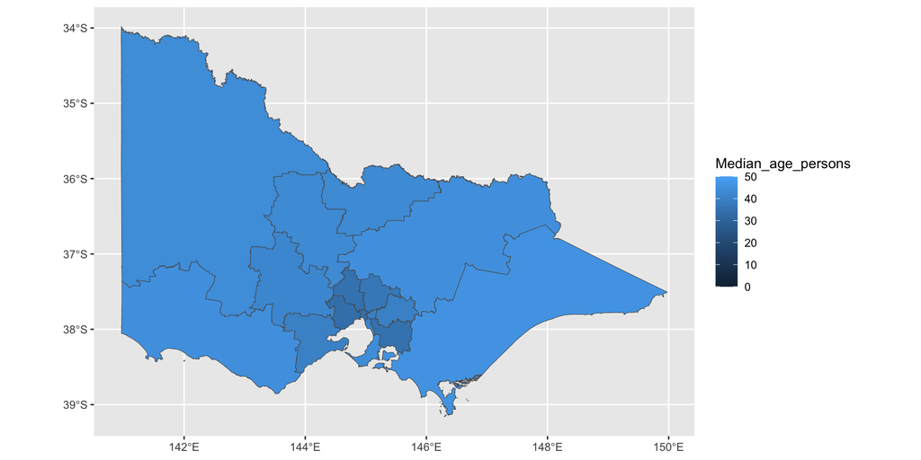

## Significant Urban Areas (SUA)

```r
vicmap_sua_G02 <- read_sf(geopath_2021_G02, layer = "G02_SUA_2021_VIC")
ggplot(vicmap_sua_G02) +
  geom_sf(aes(geometry = geom, fill = Median_age_persons))
```

```r
nrow(vicmap_sua_G02)
```

```
[1] 22
```

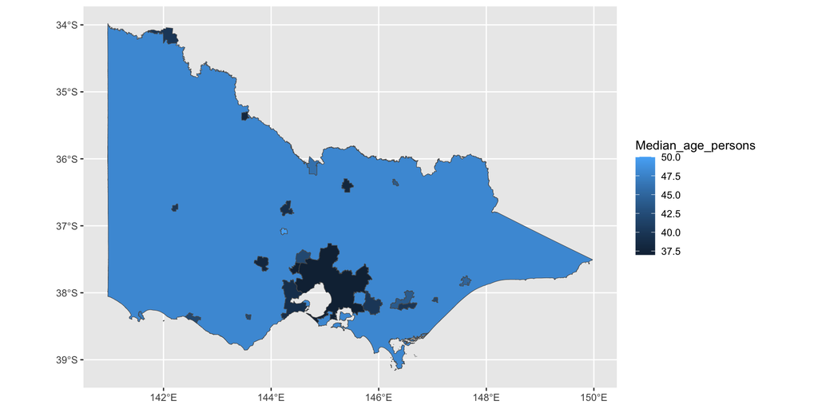

## Commonwealth Electoral Division (CED)

```r
vicmap_ced_G02 <- read_sf(geopath_2021_G02, layer = "G02_CED_2021_VIC")
ggplot(vicmap_ced_G02) +
  geom_sf(aes(geometry = geom, fill = Median_age_persons))
```

```r
nrow(vicmap_ced_G02)
```

```
[1] 41
```

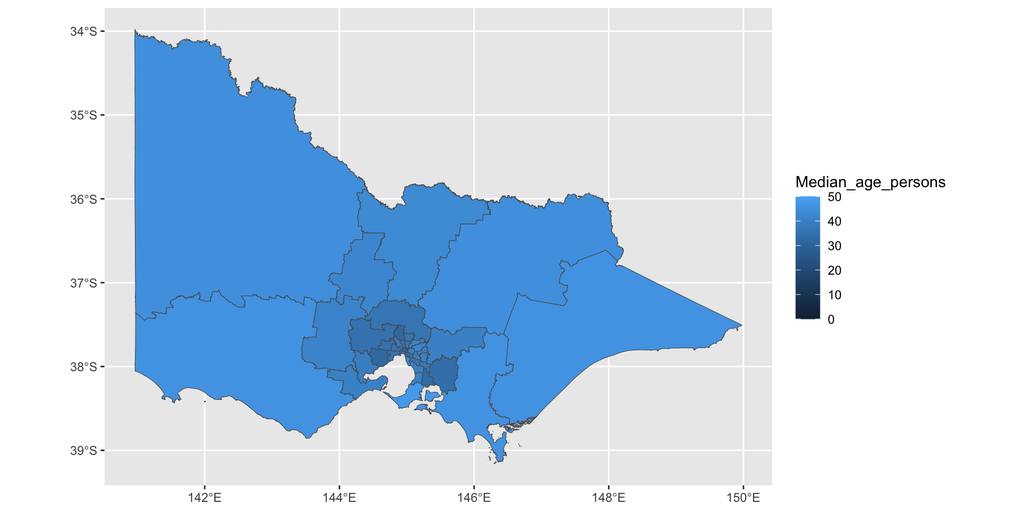

## Statistical Area Level 3 (SA3)

- Each region with population of 30,000 - 130,000

```r
vicmap_sa3_G02 <- read_sf(geopath_2021_G02, layer = "G02_SA3_2021_VIC")
ggplot(vicmap_sa3_G02) +
  geom_sf(aes(geometry = geom, fill = Median_age_persons))
```

```r
nrow(vicmap_sa3_G02)
```

```
[1] 68
```

```r
vicmap_lga_G02 <- read_sf(geopath_2021_G02, layer = "G02_SA3_2021_VIC")
ggplot(vicmap_lga_G02) +
  geom_sf(aes(geometry = geom, fill = Median_age_persons))
```

```r
nrow(vicmap_lga_G02)
```

```
[1] 68
```

## State Electoral Division (SED)

```r
vicmap_sed_G02 <- read_sf(geopath_2021_G02, layer = "G02_SED_2021_VIC")
ggplot(vicmap_sed_G02) +
  geom_sf(aes(geometry = geom, fill = Median_age_persons))
```

```r
nrow(vicmap_sed_G02)
```

```
[1] 90
```

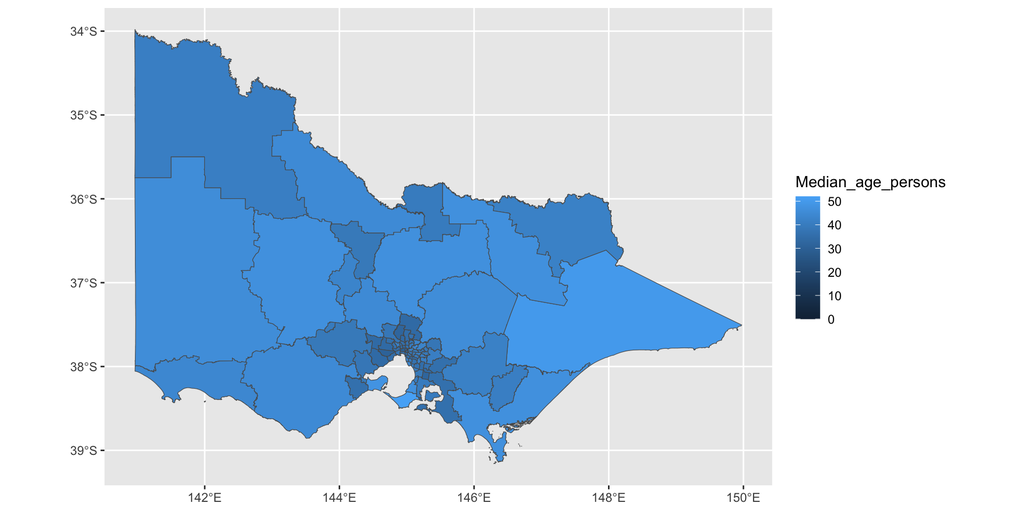

## Urban Centres and Localities (UCL)

```r
vicmap_ucl_G02 <- read_sf(geopath_2021_G02, layer = "G02_UCL_2021_VIC")
ggplot(vicmap_ucl_G02) +
  geom_sf(aes(geometry = geom, fill = Median_age_persons))
```

```r
nrow(vicmap_ucl_G02)
```

```
[1] 347
```

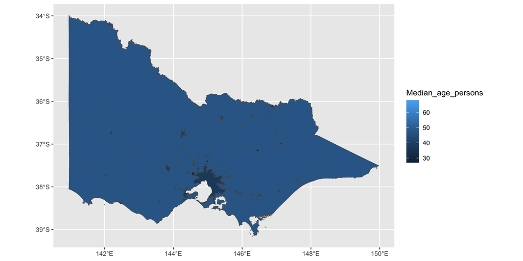

```r
vicmap_sa2_G02 <- read_sf(geopath_2021_G02, layer = "G02_SA3_2021_VIC")
ggplot(vicmap_sa2_G02) +
  geom_sf(aes(geometry = geom, fill = Median_age_persons))
```

```r
nrow(vicmap_sa2_G02)
```

```
[1] 68
```

## Postal Areas (POA)

```r
vicmap_poa_G02 <- read_sf(geopath_2021_G02, layer = "G02_POA_2021_VIC")
ggplot(vicmap_poa_G02) +
  geom_sf(aes(geometry = geom, fill = Median_age_persons))
```

```r
nrow(vicmap_poa_G02)
```

```
[1] 694
```

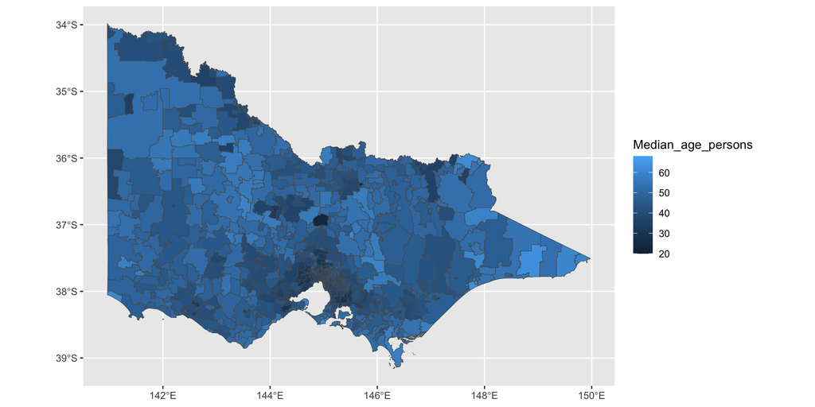

## State Area Localitites (SAL) (Formerly SSC)

```r
vicmap_sal_G02 <- read_sf(geopath_2021_G02, layer = "G02_SAL_2021_VIC")
ggplot(vicmap_sal_G02) +
  geom_sf(aes(geometry = geom, fill = Median_age_persons))
```

```r
nrow(vicmap_sal_G02)
```

```
[1] 2946
```

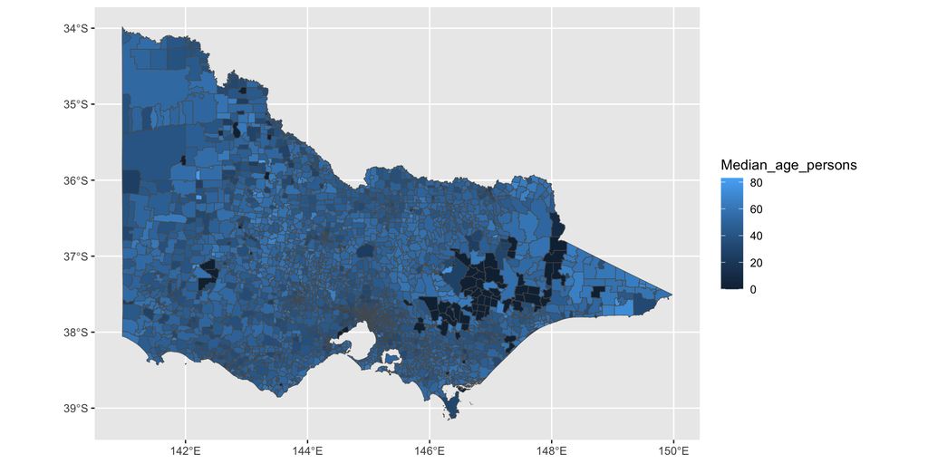

## Statistical Area Level 1 (SA1)

- Each region with a population of range 200-800

```r
vicmap_sa1_G02 <- read_sf(geopath_2021_G02, layer = "G02_SA1_2021_VIC")
ggplot(vicmap_sa1_G02) +
  geom_sf(aes(geometry = geom, fill = Median_age_persons))
```

```r
nrow(vicmap_sa1_G02)
```

```
[1] 15482
```

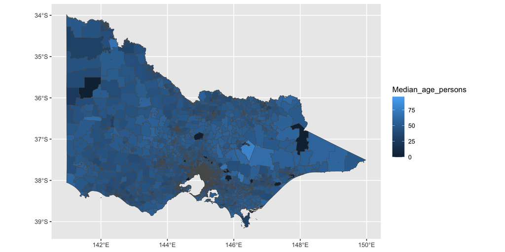

# Electorate boundary vs Census boundary

## Comparing SED 2021 and electorates divisions 2022

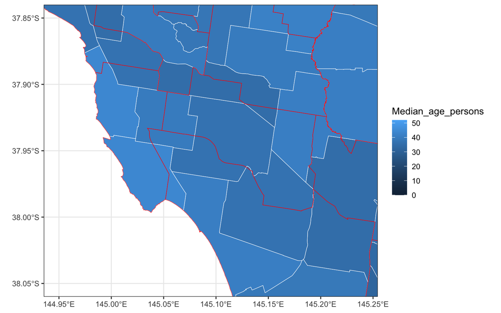

```r
ggplot() +
  geom_sf(data = vicmap_sed_G02,
          aes(geometry = geom, fill = Median_age_persons),
    alpha = 1, color = "white", size = 2) +
  geom_sf(data = winners_with_map, aes(geometry = geometry),
    fill = "transparent", color = "red", size = 2) +
  coord_sf(xlim = c(144.95, 145.24), ylim = c(-38.05, -37.85)) +
  theme_bw()
```

## Closer look: Hotham electorate 1

```r
electorate <- winners_with_map |>
  filter(DivisionNm == "HOTHAM")

# Set projection to GDA1994 using EPSG:4283
st_crs(electorate$geometry,4283)

# Transform projection from GDA1994 to GDA2020 using EPSG:7844
electorate$geometry = st_transform(electorate$geometry, 7844)

sed_intersect <- vicmap_sed_G02 |>
  filter(st_intersects(geom,
    electorate$geometry,
    sparse = FALSE
  )[, 1])

ggplot() +
  geom_sf(data = sed_intersect,
    aes(geometry = geom), color = "red", fill = "transparent") +
  geom_sf_text(data = sed_intersect,
    aes(label = SED_CODE_2021, geometry = geom), color = "red") +
  geom_sf(data = electorate, aes(geometry = geometry), fill = "transparent") +
  geom_sf_text(data = electorate, aes(geometry = geometry, label = DivisionNm))
```

## Closer look: Hotham electorate 1

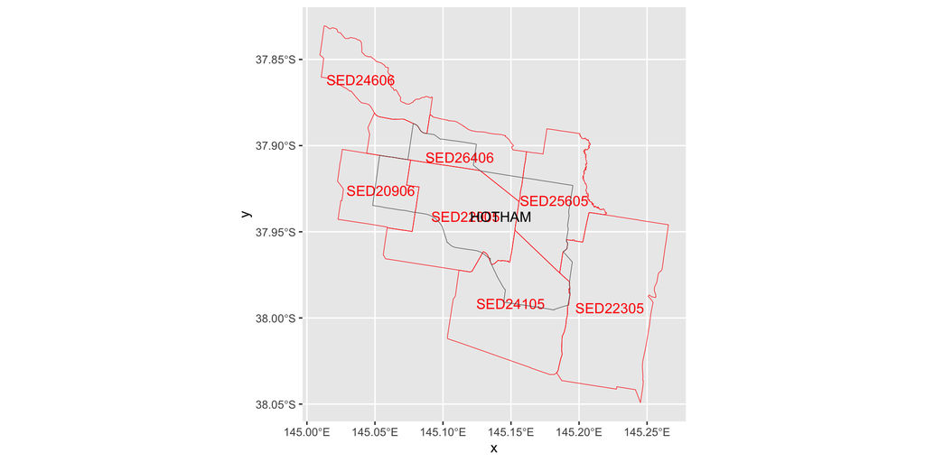

## Closer look: Hotham electorate 2

```r
sed_intersect2 <- sed_intersect |> #<<
  mutate(
    geometry = st_intersection(geom, electorate$geometry), #<<
    perc_area = 100 * st_area(geometry) / st_area(geom), #<<
    perc_area = as.numeric(perc_area)
  ) |> #<<
  filter(perc_area > 5)

ggplot(sed_intersect2, aes(geometry = geometry)) +
  geom_sf(data = electorate) +
  geom_sf_text(
    data = electorate,
    aes(label = DivisionNm)
  ) +
  geom_sf(color = "red", aes(fill = Median_age_persons)) +
  geom_sf_text(
    aes(
      label = glue::glue("{SED_CODE_2021}
                        ({scales::comma(perc_area, 1)}%, {Median_age_persons})")
    ),
    color = "red"
  ) +
  theme(legend.position = "bottom")
```

## Closer look: Hotham electorate 2

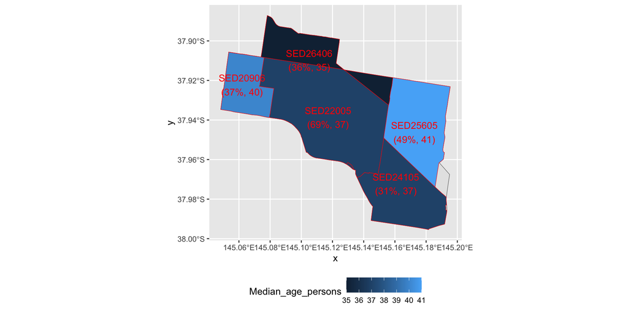

- There are 5 SED areas with at least 5% intersection with the electoral area.
- **How would you characterise the median age for Hotham?**

## Closer look: Hotham electorate 3

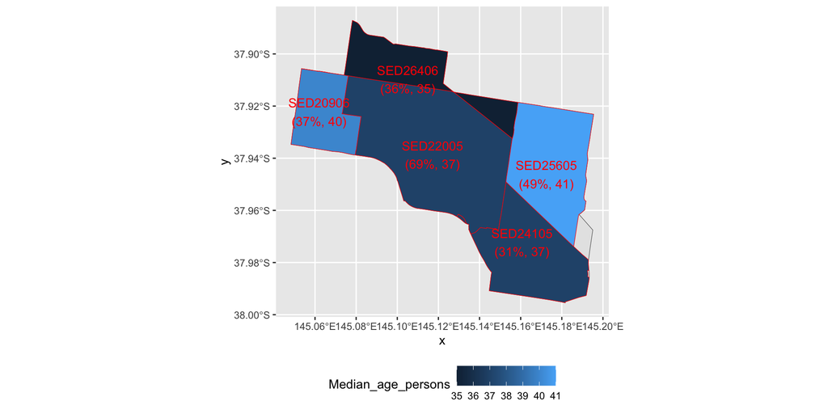

```r
sort(sed_intersect2$Median_age_persons)
```

```
[1] 35 37 37 40 41
```

```r
mean(sed_intersect2$Median_age_persons)
```

```
[1] 38
```

```r
weighted.mean(
  sed_intersect2$Median_age_persons,
  sed_intersect2$perc_area
)
```

```
[1] 38.06118
```

## Closer look: Hotham electorate 4

```r
sa1_intersect <- vicmap_sa1_G02 %>% #<<
  filter(st_intersects(geom,
    electorate$geometry,
    sparse = FALSE
  )[, 1])

sa1_intersect2 <- sa1_intersect %>%
  mutate(
    geometry = st_intersection(geom, electorate$geometry),
    perc_area = 100 * st_area(geometry) / st_area(geom),
    perc_area = as.numeric(perc_area)
  ) %>% #<<
  filter(perc_area > 5)

ggplot(sa1_intersect) +
  geom_sf(color = "red",
          aes( fill = Median_age_persons, geometry = geom)) +
  geom_sf(data = electorate,
          color = "white", size = 2, fill = "transparent",
          aes(geometry = geometry)) +
  theme(legend.position = "bottom")
```

[output not shown]

## Closer look: Hotham electorate 5

**Strategy 1**

```r
fivenum(sa1_intersect2$Median_age_persons)
```

```
[1]  0 35 38 41 81
```

**Strategy 2**

```r
mean(sa1_intersect2$Median_age_persons)
```

```
[1] 38.07674
```

**Strategy 3**

```r
weighted.mean(sa1_intersect2$Median_age_persons, sa1_intersect2$perc_area)
```

```
[1] 38.02792
```

## Closer look: Hotham electorate 5

**Strategy 4**

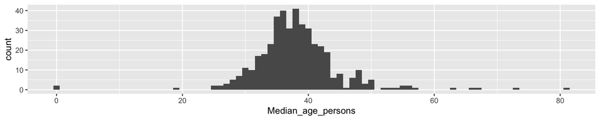

```r
ggplot(sa1_intersect2, aes(x = Median_age_persons)) +
  geom_histogram(binwidth = 1)
```

## Closer look️: Zero median age

[Hotham 2022](https://www.aec.gov.au/profiles/vic/hotham.htm)

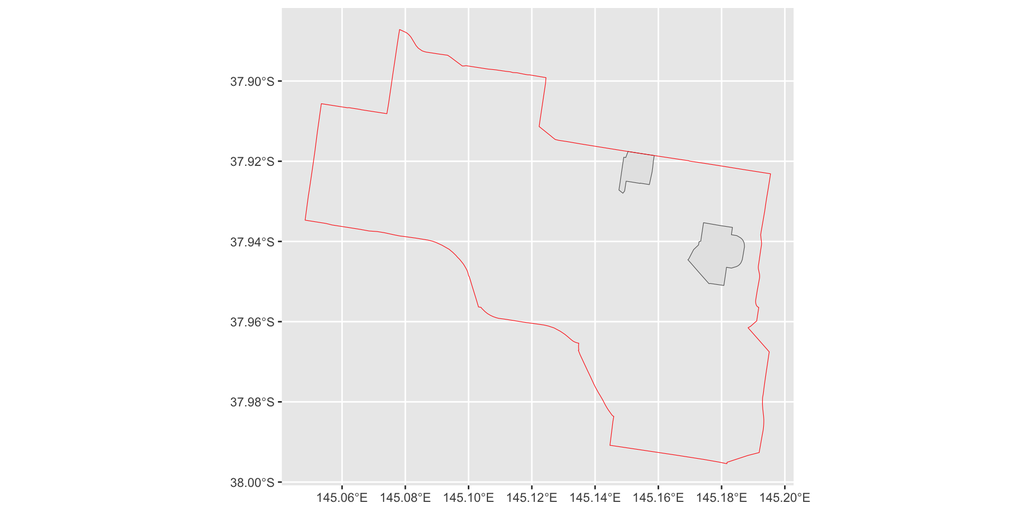

[figure not shown]

**BEFORE** (No Filter)

**Strategy 1**

```r
fivenum(sa1_intersect2$Median_age_persons)
```

```
[1]  0 35 38 41 81
```

**Strategy 2**

```r
mean(sa1_intersect2$Median_age_persons)
```

```
[1] 38.07674
```

**Strategy 3**

```r
weighted.mean(sa1_intersect2$Median_age_persons, sa1_intersect2$perc_area)
```

```
[1] 38.02792
```

**AFTER** (With Filter)

```r
sa1_intersect3 <- sa1_intersect2 %>%
  filter(Median_age_persons != 0)
```

**Strategy 1**

```r
fivenum(sa1_intersect3$Median_age_persons)
```

```
[1] 19 35 38 41 81
```

**Strategy 2**

```r
mean(sa1_intersect3$Median_age_persons)
```

```
[1] 38.25467
```

**Strategy 3**

```r
weighted.mean(sa1_intersect3$Median_age_persons, sa1_intersect3$perc_area)
```

```
[1] 38.20661
```

## Dorling Cartogram

```r
sa1_intersect4 <- sa1_intersect %>%
  mutate(centroid = st_centroid(geom))

dorling_plot <- ggplot(sa1_intersect4) +
  geom_sf(
    data = electorate,
    aes(geometry = geometry), size = 4, fill = "grey60"
  ) +
  geom_sf(aes(geometry = centroid, color = Median_age_persons),
    size = 0.5, shape = 3
  ) +
  scale_color_viridis_c(name = "Median age", option = "magma")
```

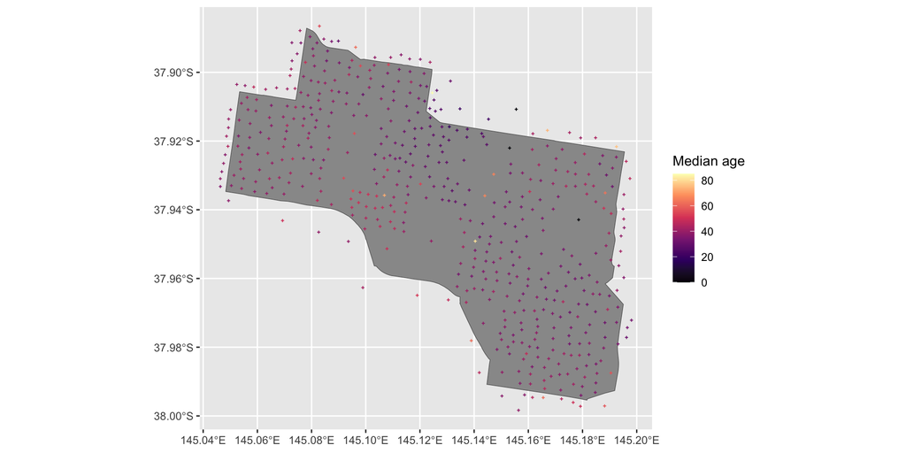

## Closer look: Hotham electorate 7

**Filter out zero age electorates**

```r
sa1_intersect5 <- sa1_intersect4 %>%
  filter(st_intersects(centroid, electorate$geometry, sparse = FALSE)[, 1],
    Median_age_persons != 0)
```

**Strategy 1**

```r
fivenum(sa1_intersect5$Median_age_persons)
```

```
[1] 19 35 38 41 81
```

**Strategy 2**

```r
mean(sa1_intersect5$Median_age_persons)
```

```
[1] 38.20706
```

**Strategy 4**

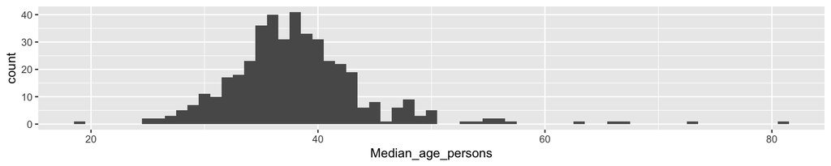

```r
ggplot(sa1_intersect5, aes(x = Median_age_persons)) +
  geom_histogram(binwidth = 1)
```

# Wrap Up

## Wrap Up

**What did we learn**

## For your assignment

**Takeaways**

- Be very clear about which boundaries you choose for your assignment and why
- Be sure to explain how you matched those boundaries - did you use area overlap, centroids, minimal area overlap criterion?
- Was there anything odd you encountered when joining your data?
- Did you need to handle any locations with no demographic data? Tell us.

## Every year

**CED regions are not the same as electoral boundaries!**

They should be a close approximation, but they won’t necesasrily be exact. Better check on your assignment! Remember I want you to justify any decisions.

## Comparing CED 2021 and electorates divisions 2022

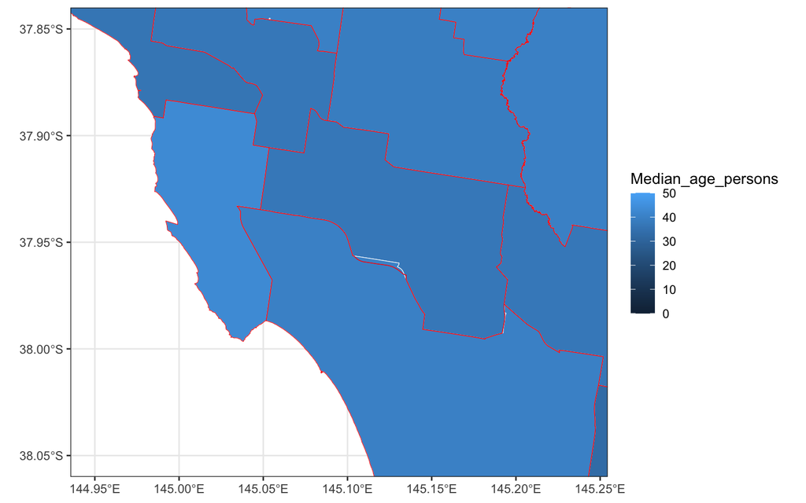

```r
ggplot() +
  geom_sf(data = vicmap_ced_G02,
          aes(geometry = geom, fill = Median_age_persons),
    alpha = 1, color = "white", size = 2) +
  geom_sf(data = winners_with_map, aes(geometry = geometry),
    fill = "transparent", color = "red", size = 2) +
  coord_sf(xlim = c(144.95, 145.24), ylim = c(-38.05, -37.85)) +
  theme_bw()
```

## Further reading

**Want to know more**

Read [Forbes, Cook & Hyndman (2020) Spatial modelling of the two-party preferred vote in Australian federal elections: 2001–2016. *Australian & New Zealand Journal of Statisitcs*.](https://onlinelibrary.wiley.com/doi/abs/10.1111/anzs.12292) for a more sophisticated approach to studying the census variables and election results together.